# *systemPipeR*: NGS workflow and report generation environment

Author: Thomas Girke (thomas.girke@ucr.edu)

Last update: 13 February, 2016

# Contents

Alternative formats of this tutorial: [`.Rmd HTML`](http://girke.bioinformatics.ucr.edu/manuals/vignettes/Rbasics/Rbasics.html), [`.Rmd Source`](http://girke.bioinformatics.ucr.edu/manuals/vignettes/Rbasics/Rbasics.Rmd), [`.R Source`](http://girke.bioinformatics.ucr.edu/manuals/vignettes/Rbasics/Rbasics.R), [`PDF Slides`](http://faculty.ucr.edu/~tgirke/HTML_Presentations/Manuals/Workshop_Dec_5_8_2014/Rbasics/Introduction_into_R.pdf)

Note: the most recent version of this tutorial can be found [here](https://htmlpreview.github.io/?https://github.com/tgirke/systemPipeR/blob/master/vignettes/systemPipeR.html) and a short overview slide show [here](https://htmlpreview.github.io/?https://github.com/tgirke/systemPipeR/master/inst/extdata/slides/systemPipeRslides.html).

# 1 Introduction

[*`systemPipeR`*](http://www.bioconductor.org/packages/devel/bioc/html/systemPipeR.html) provides utilities for building and running automated end-to-end analysis workflows for a wide range of next generation sequence (NGS) applications such as RNA-Seq, ChIP-Seq, VAR-Seq and Ribo-Seq (Girke 2014). Important features include a uniform workflow interface across different NGS applications, automated report generation, and support for running both R and command-line software, such as NGS aligners or peak/variant callers, on local computers or compute clusters. The latter supports interactive job submissions and batch submissions to queuing systems of clusters. For instance, *`systemPipeR`* can be used with most command-line aligners such as `BWA` (Heng Li 2013; H Li and Durbin 2009), `TopHat2` (Kim et al. 2013) and `Bowtie2` (Langmead and Salzberg 2012), as well as the R-based NGS aligners [*`Rsubread`*](http://www.bioconductor.org/packages/devel/bioc/html/Rsubread.html) (Liao, Smyth, and Shi 2013) and [*`gsnap (gmapR)`*](http://www.bioconductor.org/packages/devel/bioc/html/gmapR.html) (Wu and Nacu 2010). Efficient handling of complex sample sets (*e.g.* FASTQ/BAM files) and experimental designs is facilitated by a well-defined sample annotation infrastructure which improves reproducibility and user-friendliness of many typical analysis workflows in the NGS area (Lawrence et al. 2013).

Motivation and advantages of *`sytemPipeR`* environment:

1. Facilitates design of complex NGS workflows involving multiple R/Bioconductor packages
2. Common workflow interface for different NGS applications
3. Makes NGS analysis with Bioconductor utilities more accessible to new users
4. Simplifies usage of command-line software from within R
5. Reduces complexity of using compute clusters for R and command-line software
6. Accelerates runtime of workflows via parallelzation on computer systems with mutiple CPU cores and/or multiple compute nodes
7. Automates generation of analysis reports to improve reproducibility

A central concept for designing workflows within the *`sytemPipeR`* environment is the use of workflow management containers called *`SYSargs`* (see Figure 1). Instances of this S4 object class are constructed by the *`systemArgs`* function from two simple tabular files: a *`targets`* file and a *`param`* file. The latter is optional for workflow steps lacking command-line software. Typically, a *`SYSargs`* instance stores all sample-level inputs as well as the paths to the corresponding outputs generated by command-line- or R-based software generating sample-level output files, such as read preprocessors (trimmed/filtered FASTQ files), aligners (SAM/BAM files), variant callers (VCF/BCF files) or peak callers (BED/WIG files). Each sample level input/outfile operation uses its own *`SYSargs`* instance. The outpaths of *`SYSargs`* usually define the sample inputs for the next *`SYSargs`* instance. This connectivity is established by writing the outpaths with the *`writeTargetsout`* function to a new *`targets`* file that serves as input to the next *`systemArgs`* call. Typically, the user has to provide only the initial *`targets`* file. All downstream *`targets`* files are generated automatically. By chaining several *`SYSargs`* steps together one can construct complex workflows involving many sample-level input/output file operations with any combinaton of command-line or R-based software.

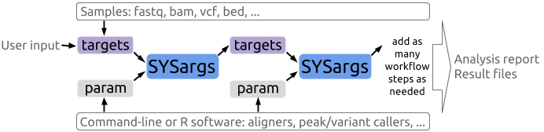

**Figure 1:** Workflow design structure of *systemPipeR*

The intended way of running *`sytemPipeR`* workflows is via *`*.Rnw`* or *`*.Rmd`* files, which can be executed either line-wise in interactive mode or with a single command from R or the command-line using a [*`Makefile`*](https://github.com/tgirke/systemPipeR/blob/master/inst/extdata/Makefile). This way comprehensive and reproducible analysis reports in PDF or HTML format can be generated in a fully automated manner by making use of the highly functional reporting utilities available for R. Templates for setting up custom project reports are provided as *`*.Rnw`* files by the helper package *`systemPipeRdata`* and in the vignettes subdirectory of *`systemPipeR`*. The corresponding PDFs of these report templates are available here: [*`systemPipeRNAseq`*](https://github.com/tgirke/systemPipeR/blob/master/vignettes/systemPipeRNAseq.pdf?raw=true), [*`systemPipeRIBOseq`*](https://github.com/tgirke/systemPipeR/blob/master/vignettes/systemPipeRIBOseq.pdf?raw=true), [*`systemPipeChIPseq`*](https://github.com/tgirke/systemPipeR/blob/master/vignettes/systemPipeChIPseq.pdf?raw=true) and [*`systemPipeVARseq`*](https://github.com/tgirke/systemPipeR/blob/master/vignettes/systemPipeVARseq.pdf?raw=true). To work with *`*.Rnw`* or *`*.Rmd`* files efficiently, basic knowledge of [*`Sweave`*](https://www.stat.uni-muenchen.de/~leisch/Sweave/) or [*`knitr`*](http://yihui.name/knitr/) and [*`Latex`*](http://www.latex-project.org/) or [*`R Markdown v2`*](http://rmarkdown.rstudio.com/) is required.

Back to Table of Contents

# 2 Getting Started

## 2.1 Installation

The R software for running [*`systemPipeR`*](http://www.bioconductor.org/packages/devel/bioc/html/systemPipeR.html) can be downloaded from [*CRAN*](http://cran.at.r-project.org/). The *`systemPipeR`* environment can be installed from R using the *`biocLite`* install command. The associated data package [*`systemPipeRdata`*](https://github.com/tgirke/systemPipeRdata) can be used to generate *`systemPipeR`* workflow environments with a single command (see below) containing all parameter files and sample data required to quickly test and run workflows.

```r
source("http://bioconductor.org/biocLite.R") # Sources the biocLite.R installation script
biocLite("systemPipeR") # Installs systemPipeR
biocLite("systemPipeRdata") # Installs systemPipeRdata
```

Back to Table of Contents

## 2.2 Loading package and documentation

```r
library("systemPipeR") # Loads the package
library(help="systemPipeR") # Lists package info
vignette("systemPipeR") # Opens vignette
```

Back to Table of Contents

## 2.3 Load sample data and workflow templates

The mini sample FASTQ files used by this overview vignette as well as the associated workflow reporting vignettes can be loaded via the *`systemPipeRdata`* package as shown below. The chosen data set [`SRP010938`](http://www.ncbi.nlm.nih.gov/sra/?term=SRP010938) contains 18 paired-end (PE) read sets from *Arabidposis thaliana* (Howard et al. 2013). To minimize processing time during testing, each FASTQ file has been subsetted to 90,000-100,000 randomly sampled PE reads that map to the first 100,000 nucleotides of each chromosome of the *A. thalina* genome. The corresponding reference genome sequence (FASTA) and its GFF annotion files (provided in the same download) have been truncated accordingly. This way the entire test sample data set requires less than 200MB disk storage space. A PE read set has been chosen for this test data set for flexibility, because it can be used for testing both types of analysis routines requiring either SE (single end) reads or PE reads.

The following loads one of the available NGS workflow templates (here RNA-Seq) into the user’s current working directory. At the moment, the package includes workflow templates for RNA-Seq, ChIP-Seq, VAR-Seq and Ribo-Seq. Templates for additional NGS applications will be provided in the future.

```r
library(systemPipeRdata)
genWorkenvir(workflow="rnaseq")
setwd("rnaseq")
```

The working environment of the sample data loaded in previous step contains the following preconfigured directory structure:

- **workflow/**
  - This is the directory of the R session running the workflow.
  - Run script ( *.Rnw or *.Rmd) and sample annotation (*targets.txt*) files are located here.
  - Note, this directory can have any name (*e.g.* **rnaseq**, **varseq**). Changing its name does not require any modifications in the run script(s).
  - Important subdirectories:
    - **param/**
      - Stores parameter files such as: *.param, *.tmpl and *_run.sh.
    - **data/**
      - FASTQ samples
      - Reference FASTA file
      - Annotations
      - etc.
    - **results/**
      - Alignment, variant and peak files (BAM, VCF, BED)
      - Tabular result files
      - Images and plots
      - etc.

The sample workflows provided by the package are based on the above directory structure, where directory names are indicated in **grey**. Users can change this structure as needed, but need to adjust the code in their workflows accordingly.

The following parameter files are included in each workflow template:

1. *`targets.txt`*: initial one provided by user; downstream *`targets_*.txt`* files are generated automatically
2. *`*.param`*: defines parameter for input/output file operations, *e.g.* *`trim.param`*, *`bwa.param`*, *`vartools.parm`*, …
3. *`*_run.sh`*: optional bash script, *e.g.*: *`gatk_run.sh`*
4. Compute cluster environment (skip on single machine):
   - *`.BatchJobs`*: defines type of scheduler for *`BatchJobs`*
   - *`*.tmpl`*: specifies parameters of scheduler used by a system, *e.g.* Torque, SGE, StarCluster, Slurm, etc.

Back to Table of Contents

## 2.4 Structure of *`targets`* file

The *`targets`* file defines all input files (*e.g.* FASTQ, BAM, BCF) and sample comparisons of an analysis workflow. The following shows the format of a sample *`targets`* file included in the package. It also can be viewed and downloaded from *`systemPipeR`*’s GitHub repository [here](https://github.com/tgirke/systemPipeR/blob/master/inst/extdata/targets.txt). In a target file with a single type of input files, here FASTQ files of single end (SE) reads, the first three columns are mandatory including their column names, while it is four mandatory columns for FASTQ files of PE reads. All subsequent columns are optional and any number of additional columns can be added as needed.

### 2.4.1 Structure of *`targets`* file for single end (SE) samples

```r
library(systemPipeR)
targetspath <- system.file("extdata", "targets.txt", package="systemPipeR")
read.delim(targetspath, comment.char = "#")
```

```
##                    FileName SampleName Factor SampleLong Experiment        Date
## 1  ./data/SRR446027_1.fastq        M1A     M1  Mock.1h.A          1 23-Mar-2012
## 2  ./data/SRR446028_1.fastq        M1B     M1  Mock.1h.B          1 23-Mar-2012
## 3  ./data/SRR446029_1.fastq        A1A     A1   Avr.1h.A          1 23-Mar-2012
## 4  ./data/SRR446030_1.fastq        A1B     A1   Avr.1h.B          1 23-Mar-2012
## 5  ./data/SRR446031_1.fastq        V1A     V1   Vir.1h.A          1 23-Mar-2012
## 6  ./data/SRR446032_1.fastq        V1B     V1   Vir.1h.B          1 23-Mar-2012
## 7  ./data/SRR446033_1.fastq        M6A     M6  Mock.6h.A          1 23-Mar-2012
## 8  ./data/SRR446034_1.fastq        M6B     M6  Mock.6h.B          1 23-Mar-2012
## 9  ./data/SRR446035_1.fastq        A6A     A6   Avr.6h.A          1 23-Mar-2012
## 10 ./data/SRR446036_1.fastq        A6B     A6   Avr.6h.B          1 23-Mar-2012
## 11 ./data/SRR446037_1.fastq        V6A     V6   Vir.6h.A          1 23-Mar-2012
## 12 ./data/SRR446038_1.fastq        V6B     V6   Vir.6h.B          1 23-Mar-2012
## 13 ./data/SRR446039_1.fastq       M12A    M12 Mock.12h.A          1 23-Mar-2012
## 14 ./data/SRR446040_1.fastq       M12B    M12 Mock.12h.B          1 23-Mar-2012
## 15 ./data/SRR446041_1.fastq       A12A    A12  Avr.12h.A          1 23-Mar-2012
## 16 ./data/SRR446042_1.fastq       A12B    A12  Avr.12h.B          1 23-Mar-2012
## 17 ./data/SRR446043_1.fastq       V12A    V12  Vir.12h.A          1 23-Mar-2012
## 18 ./data/SRR446044_1.fastq       V12B    V12  Vir.12h.B          1 23-Mar-2012
```

To work with custom data, users need to generate a *`targets`* file containing the paths to their own FASTQ files and then provide under *`targetspath`* the path to the corresponding *`targets`* file.

Back to Table of Contents

### 2.4.2 Structure of *`targets`* file for paired end (PE) samples

```r
targetspath <- system.file("extdata", "targetsPE.txt", package="systemPipeR")
read.delim(targetspath, comment.char = "#")[1:2,1:6]
```

```
##                  FileName1                FileName2 SampleName Factor SampleLong Experiment
## 1 ./data/SRR446027_1.fastq ./data/SRR446027_2.fastq        M1A     M1  Mock.1h.A          1
## 2 ./data/SRR446028_1.fastq ./data/SRR446028_2.fastq        M1B     M1  Mock.1h.B          1
```

Back to Table of Contents

### 2.4.3 Sample comparisons

Sample comparisons are defined in the header lines of the *`targets`* file starting with ‘`# <CMP>`’.

```r
readLines(targetspath)[1:4]
```

```
## [1] "# Project ID: Arabidopsis - Pseudomonas alternative splicing study (SRA: SRP010938; PMID: 24098335)"
## [2] "# The following line(s) allow to specify the contrasts needed for comparative analyses, such as DEG identification. All possible comparisons can be specified with 'CMPset: ALL'."
## [3] "# <CMP> CMPset1: M1-A1, M1-V1, A1-V1, M6-A6, M6-V6, A6-V6, M12-A12, M12-V12, A12-V12"
## [4] "# <CMP> CMPset2: ALL"
```

The function *`readComp`* imports the comparison information and stores it in a *`list`*. Alternatively, *`readComp`* can obtain the comparison information from the corresponding *`SYSargs`* object (see below). Note, these header lines are optional. They are mainly useful for controlling comparative analyses according to certain biological expectations, such as identifying differentially expressed genes in RNA-Seq experiments based on simple pair-wise comparisons.

```r
readComp(file=targetspath, format="vector", delim="-")
```

```
## $CMPset1
## [1] "M1-A1"   "M1-V1"   "A1-V1"   "M6-A6"   "M6-V6"   "A6-V6"   "M12-A12" "M12-V12" "A12-V12"
##
## $CMPset2
##  [1] "M1-A1"   "M1-V1"   "M1-M6"   "M1-A6"   "M1-V6"   "M1-M12"  "M1-A12"  "M1-V12"  "A1-V1"
## [10] "A1-M6"   "A1-A6"   "A1-V6"   "A1-M12"  "A1-A12"  "A1-V12"  "V1-M6"   "V1-A6"   "V1-V6"
## [19] "V1-M12"  "V1-A12"  "V1-V12"  "M6-A6"   "M6-V6"   "M6-M12"  "M6-A12"  "M6-V12"  "A6-V6"
## [28] "A6-M12"  "A6-A12"  "A6-V12"  "V6-M12"  "V6-A12"  "V6-V12"  "M12-A12" "M12-V12" "A12-V12"
```

Back to Table of Contents

## 2.5 Structure of *`param`* file and *`SYSargs`* container

The *`param`* file defines the parameters of a chosen command-line software. The following shows the format of a sample *`param`* file provided by this package.

```r
parampath <- system.file("extdata", "tophat.param", package="systemPipeR")
read.delim(parampath, comment.char = "#")
```

```
##      PairSet         Name                                  Value
## 1    modules         <NA>                          bowtie2/2.2.5
## 2    modules         <NA>                          tophat/2.0.14
## 3   software         <NA>                                 tophat
## 4      cores           -p                                      4
## 5      other         <NA> -g 1 --segment-length 25 -i 30 -I 3000
## 6   outfile1           -o                            <FileName1>
## 7   outfile1         path                             ./results/
## 8   outfile1       remove                                   <NA>
## 9   outfile1       append                                .tophat
## 10  outfile1 outextension              .tophat/accepted_hits.bam
## 11 reference         <NA>                    ./data/tair10.fasta
## 12   infile1         <NA>                            <FileName1>
## 13   infile1         path                                   <NA>
## 14   infile2         <NA>                            <FileName2>
## 15   infile2         path                                   <NA>
```

The *`systemArgs`* function imports the definitions of both the *`param`* file and the *`targets`* file, and stores all relevant information in a *`SYSargs`* S4 class object. To run the pipeline without command-line software, one can assign *`NULL`* to *`sysma`* instead of a *`param`* file. In addition, one can start the *`systemPipeR`* workflow with pre-generated BAM files by providing a targets file where the *`FileName`* column gives the paths to the BAM files and *`sysma`* is assigned *`NULL`*.

```r
args <- suppressWarnings(systemArgs(sysma=parampath, mytargets=targetspath))
args
```

```
## An instance of 'SYSargs' for running 'tophat' on 18 samples
```

Several accessor functions are available that are named after the slot names of the *`SYSargs`* object.

```r
names(args)
```

```
##  [1] "targetsin"     "targetsout"    "targetsheader" "modules"       "software"      "cores"
##  [7] "other"         "reference"     "results"       "infile1"       "infile2"       "outfile1"
## [13] "sysargs"       "outpaths"
```

```r
modules(args)
```

```
## [1] "bowtie2/2.2.5" "tophat/2.0.14"
```

```r
cores(args)
```

```
## [1] 4
```

```r
outpaths(args)[1]
```

```
##                                                                                                              M1A
## "/home/tgirke/Dropbox/Websites/manuals/vignettes/systemPipeR/results/SRR446027_1.fastq.tophat/accepted_hits.bam"
```

```r
sysargs(args)[1]
```

```
##                                                                                                                                                                                                                                                                                  M1A
## "tophat -p 4 -g 1 --segment-length 25 -i 30 -I 3000 -o /home/tgirke/Dropbox/Websites/manuals/vignettes/systemPipeR/results/SRR446027_1.fastq.tophat /home/tgirke/Dropbox/Websites/manuals/vignettes/systemPipeR/data/tair10.fasta ./data/SRR446027_1.fastq ./data/SRR446027_2.fastq"
```

The content of the *`param`* file can also be returned as JSON object as follows (requires *`rjson`* package).

```r
systemArgs(sysma=parampath, mytargets=targetspath, type="json")
```

```
## [1] "{\"modules\":{\"n1\":\"\",\"v2\":\"bowtie2/2.2.5\",\"n1\":\"\",\"v2\":\"tophat/2.0.14\"},\"software\":{\"n1\":\"\",\"v1\":\"tophat\"},\"cores\":{\"n1\":\"-p\",\"v1\":\"4\"},\"other\":{\"n1\":\"\",\"v1\":\"-g 1 --segment-length 25 -i 30 -I 3000\"},\"outfile1\":{\"n1\":\"-o\",\"v2\":\"<FileNam…
```

Back to Table of Contents

# 3 Workflow overview

## 3.1 Define environment settings and samples

Load packages and generate workflow environment (here for RNA-Seq)

```r
library(systemPipeR)
library(systemPipeRdata)
genWorkenvir(workflow="rnaseq")
setwd("rnaseq")
```

Construct *`SYSargs`* object from *`param`* and *`targets`* files.

```r
args <- systemArgs(sysma="param/trim.param", mytargets="targets.txt")
```

Back to Table of Contents

## 3.2 Read Preprocessing

The function *`preprocessReads`* allows to apply predefined or custom read preprocessing functions to all FASTQ files referenced in a *`SYSargs`* container, such as quality filtering or adaptor trimming routines. The paths to the resulting output FASTQ files are stored in the *`outpaths`* slot of the *`SYSargs`* object. Internally, *`preprocessReads`* uses the *`FastqStreamer`* function from the *`ShortRead`* package to stream through large FASTQ files in a memory-efficient manner. The following example performs adaptor trimming with the *`trimLRPatterns`* function from the *`Biostrings`* package. After the trimming step a new targets file is generated (here *`targets_trim.txt`*) containing the paths to the trimmed FASTQ files. The new targets file can be used for the next workflow step with an updated *`SYSargs`* instance, running the NGS alignments using the trimmed FASTQ files.

```r
preprocessReads(args=args, Fct="trimLRPatterns(Rpattern='GCCCGGGTAA', subject=fq)",
                batchsize=100000, overwrite=TRUE, compress=TRUE)
writeTargetsout(x=args, file="targets_trim.txt")
```

The following example shows how one can design a custom read preprocessing function using utilities provided by the *`ShortRead`* package, and then run it in batch mode with the *‘preprocessReads’* function (here on paired-end reads).

```r
args <- systemArgs(sysma="param/trimPE.param", mytargets="targetsPE.txt")
filterFct <- function(fq, cutoff=20, Nexceptions=0) {
    qcount <- rowSums(as(quality(fq), "matrix") <= cutoff)
    fq[qcount <= Nexceptions] # Retains reads where Phred scores are >= cutoff with N exceptions
}
preprocessReads(args=args, Fct="filterFct(fq, cutoff=20, Nexceptions=0)", batchsize=100000)
writeTargetsout(x=args, file="targets_PEtrim.txt")
```

Back to Table of Contents